# The Trouble with Normal

> *"To this may be added, that some of the Problems about Chance having a great appearance of Simplicity, the Mind is easily drawn into a belief, that their Solution may be attained by the meer Strength of natural good Sense; which generally proving otherwise, and the Mistakes occasioned thereby being not unfrequent, 'tis presumed that a Book of this Kind, which teaches to distinguish Truth from what seems so nearly to resemble it, will be looked upon as a help to good Reasoning."*

— **Abraham de Moivre, *The Doctrine of Chances* (1738)**

1. It's Only Natural
2. Central Limit Theorem
3. Maximum Entropy
4. A Closing Thought

### It's Only Natural

It has seemingly become quite ordinary to criticize the normal distribution curve and its applications in modelling heavy-tailed random variables - perhaps the financial pundits have a point but nonethless, I wanted to impart some amateur perspectives into what has made the bell-curve so prominently used in the first place. The first obvious starting point is to query whether its general form may be observed in the natural world.

I have plotted data showing the distribution of adult male heights, superimposed with the normal distribution matching the first two modes of the distribution to the dataset. It is clear that the model is adequate in fitting the data due its underlying symmetry and predictable tails. I must confess however that this was the de facto example I knew would fit nicely - if I expand this exercise to include other random variables, the presence of heavy tails and multi-modal distributions invalidates the normal approximation.

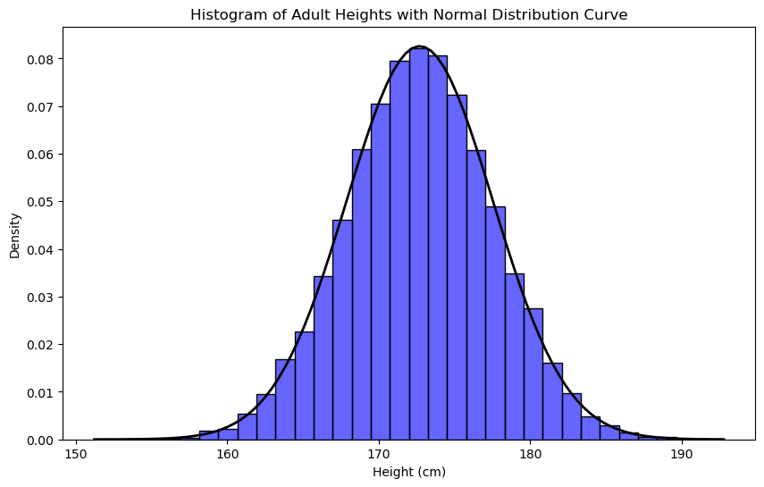

```python
import numpy as np
import pandas as pd
import matplotlib.pyplot as plt
import seaborn as sns
from scipy import stats

# Plot histogram of data
df = pd.read_csv('SOCR-HeightWeight.csv')
df['Height(cm)'] = 2.54 * df['Height(Inches)']
plt.figure(figsize=(10, 6))
sns.histplot(df['Height(cm)'] , kde=False, stat='density', bins=30, color='blue', alpha=0.6)

# Fit a normal distribution to the data
mean, std = np.mean(df['Height(cm)']), np.std(df['Height(cm)'])
xmin, xmax = plt.xlim()
x = np.linspace(xmin, xmax, 100)
p = stats.norm.pdf(x, mean, std)
plt.plot(x, p, 'k', linewidth=2)

# Add labels and title
plt.xlabel('Height (cm)')
plt.ylabel('Density')
plt.title('Histogram of Adult Heights with Normal Distribution Curve')

# Show plot
plt.show()
```

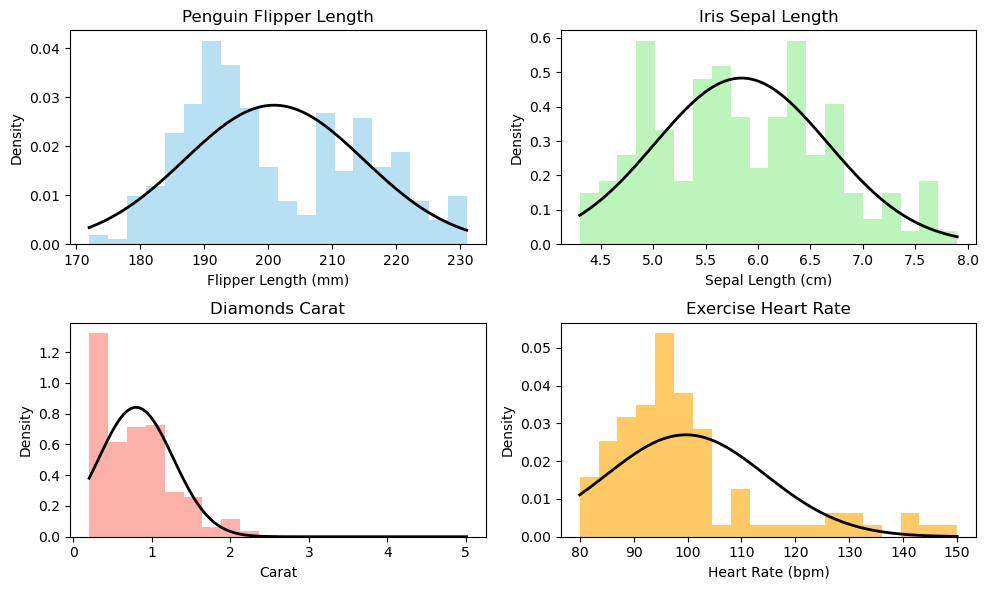

```python
import numpy as np
import matplotlib.pyplot as plt
import seaborn as sns
from scipy import stats

# Load datasets
penguins = sns.load_dataset('penguins')
iris = sns.load_dataset('iris')
diamonds = sns.load_dataset('diamonds')
exercise = sns.load_dataset('exercise')

# Create subplots
fig, axes = plt.subplots(2, 2, figsize=(10, 6))

# Plot 1: Penguin flipper length
flipper_length = penguins['flipper_length_mm'].dropna()
axes[0, 0].hist(flipper_length, bins=20, density=True, color='skyblue', alpha=0.6)
mean_flipper, std_flipper = np.mean(flipper_length), np.std(flipper_length)
x_flipper = np.linspace(flipper_length.min(), flipper_length.max(), 100)
p_flipper = stats.norm.pdf(x_flipper, mean_flipper, std_flipper)
axes[0, 0].plot(x_flipper, p_flipper, 'k', linewidth=2)
axes[0, 0].set_title('Penguin Flipper Length')
axes[0, 0].set_xlabel('Flipper Length (mm)')
axes[0, 0].set_ylabel('Density')

# Plot 2: Iris sepal length
sepal_length = iris['sepal_length']
axes[0, 1].hist(sepal_length, bins=20, density=True, color='lightgreen', alpha=0.6)
mean_sepal, std_sepal = np.mean(sepal_length), np.std(sepal_length)
x_sepal = np.linspace(sepal_length.min(), sepal_length.max(), 100)
p_sepal = stats.norm.pdf(x_sepal, mean_sepal, std_sepal)
axes[0, 1].plot(x_sepal, p_sepal, 'k', linewidth=2)
axes[0, 1].set_title('Iris Sepal Length')
axes[0, 1].set_xlabel('Sepal Length (cm)')
axes[0, 1].set_ylabel('Density')

# Plot 3: Diamonds carat
carat = diamonds['carat'].dropna()
axes[1, 0].hist(carat, bins=20, density=True, color='salmon', alpha=0.6)
mean_carat, std_carat = np.mean(carat), np.std(carat)
x_carat = np.linspace(carat.min(), carat.max(), 100)
p_carat = stats.norm.pdf(x_carat, mean_carat, std_carat)
axes[1, 0].plot(x_carat, p_carat, 'k', linewidth=2)
axes[1, 0].set_title('Diamonds Carat')
axes[1, 0].set_xlabel('Carat')
axes[1, 0].set_ylabel('Density')

# Plot 4: Exercise heart rate
heart_rate = exercise['pulse'].dropna()
axes[1, 1].hist(heart_rate, bins=20, density=True, color='orange', alpha=0.6)
mean_heart_rate, std_heart_rate = np.mean(heart_rate), np.std(heart_rate)
x_heart_rate = np.linspace(heart_rate.min(), heart_rate.max(), 100)
p_heart_rate = stats.norm.pdf(x_heart_rate, mean_heart_rate, std_heart_rate)
axes[1, 1].plot(x_heart_rate, p_heart_rate, 'k', linewidth=2)
axes[1, 1].set_title('Exercise Heart Rate')
axes[1, 1].set_xlabel('Heart Rate (bpm)')
axes[1, 1].set_ylabel('Density')

# Adjust layout
plt.tight_layout()
plt.show()
```

### Central Limit Theorem

De Moivre first discovered a method for approximating the sum of the terms of a binomial, which gave form to the normal distribution curve. This is perhaps best recollected by visualising Pascal's triangle which provides the coefficients of a binomial expansion. As one rolls down the triangle, the converging form is normal.

A similar conclusion is reached through the following exercise: assume a game where one must guess any assigned real number between 0 and 1. The resulting probability distribution function is shown in the first histogram when repeated a million times. Intuitively, no result is meaningfully more likely than the others and so any random guess will do. If we now iterate on the rules and ask to guess the sum of two randomly assigned numbers, the resulting triangular distribution shows the most likely outcome as the *centre* of all possibilities. With subsequent summations, the resultant distributions approach normality or in other words, the sum of many independent random variables converges to the bell-curve regardless of its original distribution (n=1). This is a fabulous result in the context of measurement errors upon which we can now assume some functional form. Indeed, this forms the basis for the least squares approach when building confidence intervals around estimated coefficients.

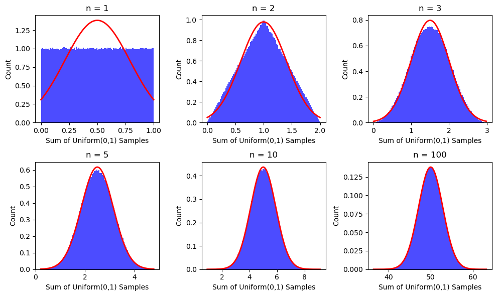

```python
import random
import matplotlib.pyplot as plt
import numpy as np
import scipy.stats as stats

fig, axs = plt.subplots(2, 3, figsize=(10, 6))
axs = axs.flatten()
n_values = [1, 2, 3, 5, 10, 100]

for idx, n in enumerate(n_values):
    sample = list()
    for i in range(0, 1000000):
        item = sum(random.uniform(0, 1) for _ in range(n))
        sample.append(item)
    mean_value = np.mean(sample)
    std_value = np.std(sample)
    axs[idx].hist(sample, bins=100, alpha=0.7, color='blue', density=True)
    x = np.linspace(min(sample), max(sample), 1000)
    normal_dist = stats.norm.pdf(x, mean_value, std_value)
    axs[idx].plot(x, normal_dist, color='red', linewidth=2)
    axs[idx].set_title(f'n = {n}')
    axs[idx].set_xlabel('Sum of Uniform(0,1) Samples')
    axs[idx].set_ylabel('Count')
plt.tight_layout()
plt.show()
```

### Maximum Entropy

The defining equation for the normal distribution takes the form of the exponential of a negative parabola ($e^{-x^2}$). One can better understand the characteristics of this distribution when thinking in terms of its governing equation. For example, what would the resultant distribution be if we modifed the applied exponent? In the below plots, I have shown three alternative equations which could in theory be contenders for pre-eminence. Simply taking the negative absolute exponent would result in a rather agressive form as both sides of the curve collide at its centre. This lack of concavity would make the modal point relatively more probable compared to virtually identical variates. On the other hand, raising the exponent to higher powers would cause very soft-tailed distributions where extreme outcomes would be nearly impossible. From this, it is safe to assume that the quadratic form is not insensible as it is the least biased distribution given a certain mean and standard deviation.

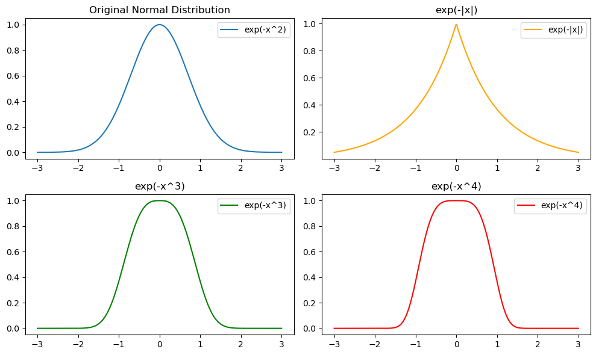

```python
import numpy as np
import matplotlib.pyplot as plt

x = np.linspace(-3, 3, 400)
y_original = np.exp(-x**2)
y_abs = np.exp(-np.abs(x))
y_cubed = np.exp(-abs(x**3))
y_fourth = np.exp(-x**4)

fig, axs = plt.subplots(2, 2, figsize=(10, 6))
axs[0, 0].plot(x, y_original, label='exp(-x^2)')
axs[0, 0].set_title('Original Normal Distribution')
axs[0, 0].legend()
axs[0, 1].plot(x, y_abs, label='exp(-|x|)', color='orange')
axs[0, 1].set_title('exp(-|x|)')
axs[0, 1].legend()
axs[1, 0].plot(x, y_cubed, label='exp(-x^3)', color='green')
axs[1, 0].set_title('exp(-x^3)')
axs[1, 0].legend()
axs[1, 1].plot(x, y_fourth, label='exp(-x^4)', color='red')
axs[1, 1].set_title('exp(-x^4)')
axs[1, 1].legend()
plt.tight_layout()
plt.show()
```

### A Closing Thought

I would surmise that when de Moivre introduced his method of approximations, that he did not imagine how widespread the bell curve would come to be in the modern world. His intention was to create a tool to complement common sense, not replace it. It is incumbent on users to be well-versed in such tools, just as a machinist must know the limits of each instrument she has at her disposal. To that end, the title of this write-up is misleading - there is nothing wrong with normal distributions, only false applications. We must not shift the onus away from personal accountability and sensibility, lest we should continue to fail to distinguish Truth from what seems so nearly to resemble it.